# Testing Sankay Charts and other Graphs of Graphs and Trees

```r
library(tidyverse)
library(networkD3)
```

# Testing The Sankey Charts from `networkD3`

The following example is modified from a stack overflow post: https://stackoverflow.com/questions/52895046/structuring-binary-data-for-sankey-plot/52895853#52895853

## Generate Random Data

```r
set.seed(900)
n=100
example.data<-data.frame(A = rep(1,n),
                         B = sample(c(0,1),n,replace = TRUE)) %>%
  mutate(C = sample(c(0,1),n,prob = c(0.3,0.7),replace = TRUE),
         D = sample(c(0,1),n,prob = c(0.85,0.15),replace = TRUE))
```

## Pivot data to long form

```r
events <- example.data %>%
  mutate(row = row_number()) %>%
  pivot_longer(-row, names_to = "column", values_to = "choice" ) %>%

  mutate(column_num = match(column, names(example.data))) %>%
  arrange(row, column_num) %>%
  select(row, column_num, everything())
```

## Create “target” and “source” columns

The coding is based on the knowledge that if you group by row, the first item in each row is from column A, and the last was from column D. When you you `lag()` the data within that row, the first item will always be `NA`. We end up with “source” values that have `NA` wherever a column A value would have been. We then filter out any NAs. I dont believe it is essential to filter out the `NA`s….

What I find weird here is the terminology. I want the “source” to be to the left, but that’s not the way this package is constructed. The on-line help provides no real help in figuring out why.

```r
links1 <-
  events %>%
  mutate(target = paste0(column, "_", choice)) %>%
  group_by(row) %>%
  mutate(source = lag(target)) %>%
  ungroup()

links1.1 <- links1 %>%
  filter(!is.na(source) & !is.na(target))
```

```r
links2 <-
  links1.1 %>%
  select(source, target) %>%
  group_by(source, target) %>%
  summarise(value = n(), .groups = 'drop') %>%
  ungroup()
```

## Create a Dateframe of Node Names

At this point we have a Links dataframe, but with text names for each node. The `networkD3` package wants nodes identified numerically, with names isolated in a separate dataframe.

I create a dataframe containing names for all the nodes…

```r
nodes <- data.frame(name = unique(c(links2$source, links2$target)))
```

## Generate the Plot

Finally, I replace all the node string values in links with numeric codes, zero indexed.

```r
links3 <- links2 %>%
  mutate(source = match(source, nodes$name) - 1,
         target = match(target, nodes$name) - 1)

plt <- sankeyNetwork(Links = links3,
             Source = "source", Target = "target", Value = "value",
             Nodes = nodes,
             NodeID = "name", nodeWidth = 25, nodePadding = 20,
             fontSize = 48)
```

```
Links is a tbl_df. Converting to a plain data frame.
```

```r
plt
```

[interactive chart not shown]

## Save the Output

The graphic is not easy to save programmatically. The save functionality produces an HTML widget. A problem in `rmarkdown` functions that are actually called to generate the saved HTML prevents saving this as a self-contained HTML file.

```r
saveNetwork(plt, file = 'sankay.html', selfcontained = TRUE)
```

```
[WARNING] Deprecated: --self-contained. use --embed-resources --standalone
```

# Testing a Simple Graph from `networkD3`

`simpleNetwork` Generates a force directed network graph, again as an HTML Widget. The following example is from the related help page.

```r
src <- c("A", "A", "A", "A", "B", "B", "C", "C", "D")
target <- c("B", "C", "D", "J", "E", "F", "G", "H", "I")
networkData <- data.frame(src, target)

sn <- simpleNetwork(networkData, fontSize = 12)
sn
```

[interactive chart not shown]

# Testing a Hierarchical Tree from `networkD3`

The following example is from the help file for `diagonalNetwork()`.

`diagonalNetwork()` generates a “Reingold-Tilford Tree” network diagram

```r
CanadaPC <- list(name = "Canada", children = list(list(name = "Newfoundland",
                    children = list(list(name = "St. John's"))),
               list(name = "PEI",
                    children = list(list(name = "Charlottetown"))),
               list(name = "Nova Scotia",
                    children = list(list(name = "Halifax"))),
               list(name = "New Brunswick",
                    children = list(list(name = "Fredericton"))),
               list(name = "Quebec",
                    children = list(list(name = "Montreal"),
                                    list(name = "Quebec City"))),
               list(name = "Ontario",
                    children = list(list(name = "Toronto"),
                                    list(name = "Ottawa"))),
               list(name = "Manitoba",
                    children = list(list(name = "Winnipeg"))),
               list(name = "Saskatchewan",
                    children = list(list(name = "Regina"))),
               list(name = "Nunavuet",
                    children = list(list(name = "Iqaluit"))),
               list(name = "NWT",
                    children = list(list(name = "Yellowknife"))),
               list(name = "Alberta",
                    children = list(list(name = "Edmonton"))),
               list(name = "British Columbia",
                    children = list(list(name = "Victoria"),
                                    list(name = "Vancouver"))),
               list(name = "Yukon",
                    children = list(list(name = "Whitehorse")))
))

diagonalNetwork(List = CanadaPC, fontSize = 10)
```

[interactive chart not shown]

```r
NA
```

# Testing the `data.tree` Package

This package handles creation of hierarchical data.

Much of the following is from the package vignettes.

```r
library('data.tree')
```

```r
acme <- Node$new("Acme Inc.")
  accounting <- acme$AddChild("Accounting")
    software <- accounting$AddChild("New Software")
    standards <- accounting$AddChild("New Accounting Standards")
  research <- acme$AddChild("Research")
    newProductLine <- research$AddChild("New Product Line")
    newLabs <- research$AddChild("New Labs")
  it <- acme$AddChild("IT")
    outsource <- it$AddChild("Outsource")
    agile <- it$AddChild("Go agile")
    goToR <- it$AddChild("Switch to R")

print(acme)
```

| levelName |
| --- |
| Acme Inc. |
| ¦--Accounting |
| ¦ ¦--New Software |
| ¦ °--New Accounting Standards |
| ¦--Research |
| ¦ ¦--New Product Line |
| ¦ °--New Labs |
| °--IT |
| ¦--Outsource |
| ¦--Go agile |

[output cut: 1 more lines]

Plotting is managed through `DiagrammeR`, which has lots of formatting options. `DiagrammeR` is itself builds on `graphviz`

```r
library(DiagrammeR)
plot(acme)
```

[interactive chart not shown]

## Loading Data from the `treemap` package

```r
library(treemap)
data(GNI2014)
head(GNI2014)
```

|  | iso3 | country | continent | population | GNI |
| --- | --- | --- | --- | --- | --- |
| 3 | BMU | Bermuda | North America | 67837 | 106140 |
| 4 | NOR | Norway | Europe | 4676305 | 103630 |
| 5 | QAT | Qatar | Asia | 833285 | 92200 |
| 6 | CHE | Switzerland | Europe | 7604467 | 88120 |
| 7 | MAC | Macao SAR, China | Asia | 559846 | 76270 |
| 8 | LUX | Luxembourg | Europe | 491775 | 75990 |

## Building a Tree based on that Tabular Data

```r
GNI2014$pathString <- paste("world",
                            GNI2014$continent,
                            GNI2014$country,
                            sep = "/")
```

The following call o `as.Node()` implicitly calls `FromDataFrameTable()`, where a lot of the heavy lifting occurs.

```r
population <- as.Node(GNI2014)
print(population, "iso3", "population", "GNI", limit = 20)
```

| levelName | iso3 | population | GNI |
| --- | --- | --- | --- |
| world | NA | NA | NA |
| ¦--North America | NA | NA | NA |
| ¦ ¦--Bermuda | BMU | 67837 | 106140 |
| ¦ ¦--United States | USA | 313973000 | 55200 |
| ¦ ¦--Canada | CAN | 33487208 | 51630 |
| ¦ ¦--Bahamas, The | BHS | 309156 | 20980 |
| ¦ ¦--Trinidad and Tobago | TTO | 1310000 | 20070 |
| ¦ ¦--Puerto Rico | PRI | 3971020 | 19310 |
| ¦ ¦--Barbados | BRB | 284589 | 15310 |
| ¦ ¦--St. Kitts and Nevis | KNA | 40131 | 14920 |

[output cut: 11 more lines]

I also read about the `igraph` package…. `igraph` manages graphs, as in graph theory – collections of nodes and links. It’s a big package. I’ve just scratched the surface.

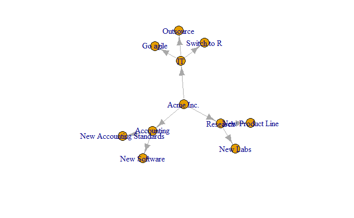

```r
library(igraph)
ig <- as.igraph(acme, directed = TRUE, direction = "climb")
plot(ig)
```

That is plotted with standard R graphics, so export requires opening a graphics device….

```r
print(ig)
```

```
IGRAPH e4c0b1f DN-- 11 10 --
+ attr: name (v/c)
+ edges from e4c0b1f (vertex names):
 [1] Acme Inc. ->Accounting               Acme Inc. ->Research
 [3] Acme Inc. ->IT                       Accounting->New Software
 [5] Accounting->New Accounting Standards Research  ->New Product Line
 [7] Research  ->New Labs                 IT        ->Outsource
 [9] IT        ->Go agile                 IT        ->Switch to R
```

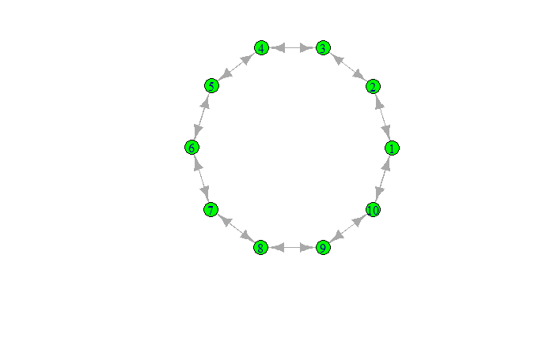

```r
g <- make_ring(10, directed = TRUE, mutual = TRUE)
plot(g, layout=layout_with_kk, vertex.color="green")
```

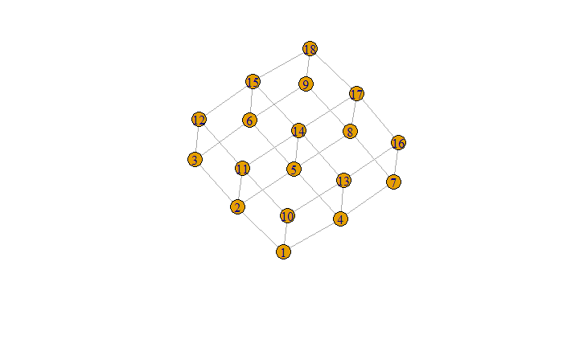

```r
l <- make_lattice(c(3, 3, 2))
plot(l)
```